# Exploratory Data Visualizations

Joan Wang

October 15, 2017

### Child Labor

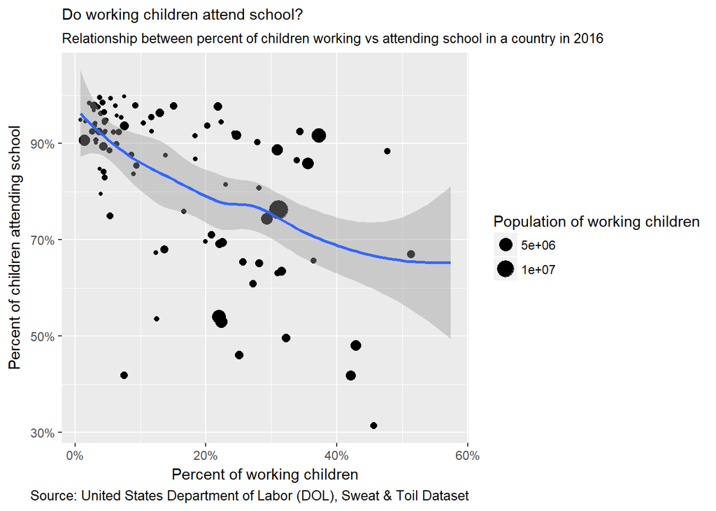

```r
stats_2016 <- filter(statistics, year == 2016)
ggplot(data=stats_2016, aes(x=percent_of_working_children, y=percent_of_children_attending_school)) +
  geom_point(na.rm=TRUE, aes(size=population_of_working_children)) +
  geom_smooth(model = lm) +
  labs(title = "Do working children attend school?",
       subtitle = "Relationship between percent of children working vs attending school in a country in 2016",
       x = "Percent of working children",
       y = "Percent of children attending school",
       size = "Population of working children",
       caption = "Source: United States Department of Labor (DOL), Sweat & Toil Dataset") +
  theme(plot.title = element_text(size=11), legend.position='right') +
  scale_x_continuous(labels = scales::percent) +
  scale_y_continuous(labels = scales::percent)
```

This scatterplot suggests that countries with more children at work have fewer children attending school. Child labor is harmful to children for a number of reasons, one of which is the deprivation of time that could be used toward education. A lack of education among child laborers could lead to further economic disadvantages in the future, thus perpetuating the cycle.

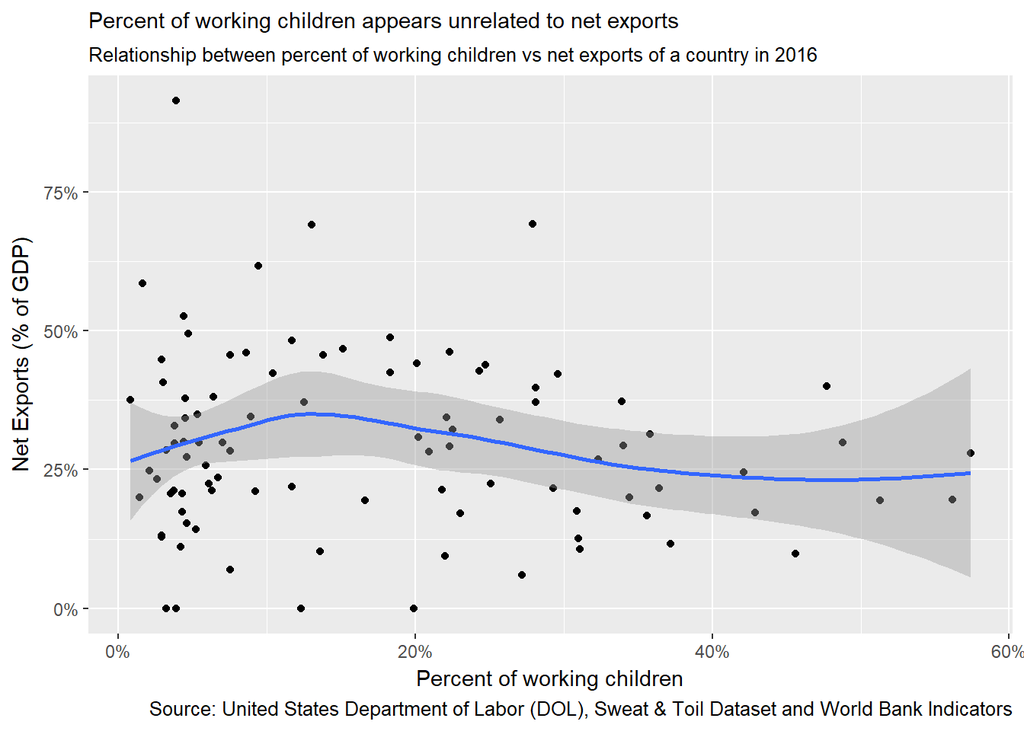

```r
countries_stats_2016 = left_join(countries, filter(rename(statistics, "name_DOL" = country), year == 2016), by="name_DOL")

ggplot(data=countries_stats_2016, aes(x=percent_of_working_children, y=net_exports_2015)) +
  geom_point(na.rm=TRUE) +
  geom_smooth(model = lm) +
  labs(title = "Percent of working children appears unrelated to net exports",
       subtitle = "Relationship between percent of working children vs net exports of a country in 2016",
       x = "Percent of working children",
       y = "Net Exports (% of GDP)",
       caption = "Source: United States Department of Labor (DOL), Sweat & Toil Dataset and World Bank Indicators") +
  theme(plot.title = element_text(size=11)) +
  scale_x_continuous(labels = scales::percent) +
  scale_y_continuous(labels = scales::percent)
```

One may wonder if child labor is related to the level of net exports in a country. Do countries that primarily export goods to other countries utilize child labor to meet those demands? Although the answer to this question requires further research, the scatterplot above suggests that there is no immediate association between net exports (as a % of GDP) and child labor in a country.

### Goods Produced by Child or Forced Labor

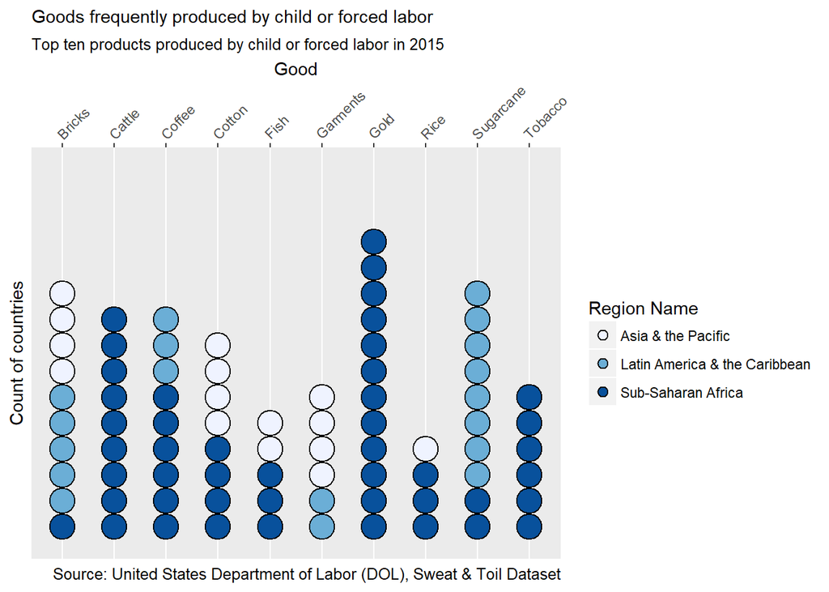

```r
country_goods$good = factor(country_goods$good)
country_goods_2015 <- filter(country_goods, year == 2015)
freq_goods <- count(country_goods_2015, good) %>%
  arrange(desc(n)) %>%
  top_n(10)

ggplot(data=subset(country_goods_2015,good %in% freq_goods$good), aes(good)) +
  geom_dotplot(binwidth=0.5, method='histodot', aes(fill=regionname)) +
  scale_y_continuous(name = "Count of countries", breaks = NULL) +
  scale_x_discrete(position = 'top') +
  labs(title = "Goods frequently produced by child or forced labor",
       subtitle = "Top ten products produced by child or forced labor in 2015",
       x = "Good",
       fill = "Region Name",
       caption = "Source: United States Department of Labor (DOL), Sweat & Toil Dataset")+
  theme(plot.title = element_text(size=11), axis.text.x = element_text(angle = 45, hjust = 0)) +
  scale_fill_brewer(drop=TRUE, breaks=c('Asia & the Pacific', 'Latin America & the Caribbean', 'Sub-Saharan Africa'))
```

### Assessment of Efforts

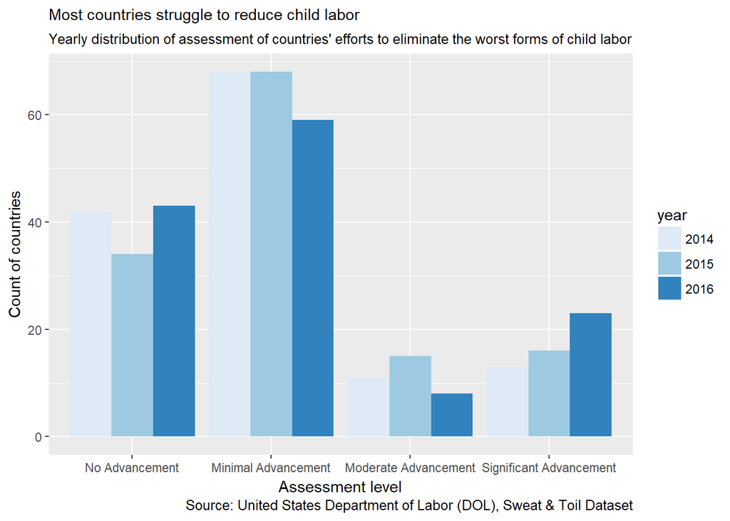

```r
assessments$year <-factor(assessments$year)

assessments$advancement_level <-factor(assessments$advancement_level)
levels(assessments$advancement_level) <- c("No Advancement", "Minimal Advancement", "Moderate Advancement", "Significant Advancement")
ggplot(data=na.omit(assessments), aes(x=advancement_level, group=year, fill=year)) +
  geom_bar(na.rm=TRUE, position='dodge') +
  labs(title = "Most countries struggle to reduce child labor",
       subtitle = "Yearly distribution of assessment of countries' efforts to eliminate the worst forms of child labor ",
       x = "Assessment level",
       y = "Count of countries",
       caption = "Source: United States Department of Labor (DOL), Sweat & Toil Dataset") +
  theme(plot.title = element_text(size=11)) +
  scale_fill_brewer()
```

The Department of Labor’s reports on Child and Forced Labor note the actions that each country has taken each year to address this issue. A few countries have made moderate or significant advancements to eliminate the worst forms of child labor. However, most countries have made little to no advancement in efforts to reduce child labor in the past three years.

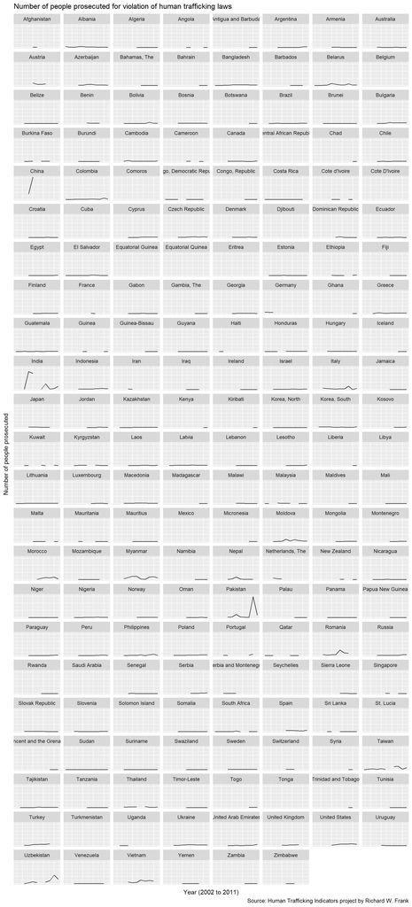

```r
ggplot(data=indicators, aes(x=year, y=prosnum, group=1)) +
  geom_line() +
  facet_wrap(~ country, ncol=8) +
  theme(axis.text.x=element_blank(),
  axis.ticks.x=element_blank(),
  axis.text.y=element_blank(),
  axis.ticks.y=element_blank(),
  strip.text = element_text(size=9)) +
  labs(title = "Number of people prosecuted for violation of human trafficking laws",
       x = "Year (2002 to 2011)",
       y = "Number of people prosecuted",
       caption = "Source: Human Trafficking Indicators project by Richard W. Frank")
```

Here, we see a high level overview of the change in the number of individuals prosecuted in each country, between 2002 to 2011. China, India, and Pakistan have experienced drastic increases in their prosecution numbers. It would be interesting to research the actions and outcomes around these spikes.